# ML Mini Project

```python
import pandas as pd
import numpy as np
import matplotlib.pyplot as plt
import seaborn as sns
```

```python
df_train= pd.read_csv('C:\\Users\\Admin\\Downloads\\datasets_o4r_4d0uxogf (1)\Datasets\\Consumer_Complaints_train.csv')
```

```python
df_train.head()
```

|  | Date received | Product | Sub-product | Issue | Sub-issue | Consumer complaint narrative | Company public response | Company | State | ZIP code | Tags | Consumer consent provided? | Submitted via | Date sent to company | Company response to consumer | Timely response? | Consumer disputed? | Complaint ID |
| --- | --- | --- | --- | --- | --- | --- | --- | --- | --- | --- | --- | --- | --- | --- | --- | --- | --- | --- |
| 0 | 2015-10-14 | Credit reporting | NaN | Incorrect information on credit report | Information is not mine | NaN | NaN | Equifax | GA | 30134 | NaN | Consent not provided | Web | 2015-10-14 | Closed with explanation | Yes | No | 1605653 |
| 1 | 2015-04-26 | Bank account or service | Other bank product/service | Deposits and withdrawals | NaN | RE : XXXX XXXX XXXX-PRIVILEGED AND CONFIDENTIA... | NaN | Wells Fargo & Company | GA | 319XX | NaN | Consent provided | Web | 2015-04-26 | Closed with explanation | Yes | Yes | 1347613 |
| 2 | 2013-12-20 | Credit card | NaN | Other | NaN | NaN | NaN | Citibank | SC | 29203 | NaN | NaN | Phone | 2014-01-03 | Closed with non-monetary relief | Yes | No | 640394 |
| 3 | 2016-03-03 | Debt collection | Other (i.e. phone, health club, etc.) | Disclosure verification of debt | Not given enough info to verify debt | NaN | Company has responded to the consumer and the ... | FAIR COLLECTIONS & OUTSOURCING, INC. | OH | 43082 | NaN | NaN | Referral | 2016-03-04 | Closed with explanation | Yes | No | 1815134 |
| 4 | 2015-01-30 | Debt collection | Medical | Disclosure verification of debt | Not given enough info to verify debt | NaN | NaN | HCFS Health Care Financial Services, Inc. | CA | 90036 | NaN | NaN | Web | 2015-01-30 | Closed with explanation | Yes | Yes | 1218613 |

```python
df_test=pd.read_csv('C:\\Users\\Admin\\Downloads\\datasets_o4r_4d0uxogf (1)\\Datasets\\Consumer_Complaints_test.csv')
```

```python
df_train.head()
```

|  | Date received | Product | Sub-product | Issue | Sub-issue | Consumer complaint narrative | Company public response | Company | State | ZIP code | Tags | Consumer consent provided? | Submitted via | Date sent to company | Company response to consumer | Timely response? | Consumer disputed? | Complaint ID |
| --- | --- | --- | --- | --- | --- | --- | --- | --- | --- | --- | --- | --- | --- | --- | --- | --- | --- | --- |
| 0 | 2015-10-14 | Credit reporting | NaN | Incorrect information on credit report | Information is not mine | NaN | NaN | Equifax | GA | 30134 | NaN | Consent not provided | Web | 2015-10-14 | Closed with explanation | Yes | No | 1605653 |
| 1 | 2015-04-26 | Bank account or service | Other bank product/service | Deposits and withdrawals | NaN | RE : XXXX XXXX XXXX-PRIVILEGED AND CONFIDENTIA... | NaN | Wells Fargo & Company | GA | 319XX | NaN | Consent provided | Web | 2015-04-26 | Closed with explanation | Yes | Yes | 1347613 |
| 2 | 2013-12-20 | Credit card | NaN | Other | NaN | NaN | NaN | Citibank | SC | 29203 | NaN | NaN | Phone | 2014-01-03 | Closed with non-monetary relief | Yes | No | 640394 |
| 3 | 2016-03-03 | Debt collection | Other (i.e. phone, health club, etc.) | Disclosure verification of debt | Not given enough info to verify debt | NaN | Company has responded to the consumer and the ... | FAIR COLLECTIONS & OUTSOURCING, INC. | OH | 43082 | NaN | NaN | Referral | 2016-03-04 | Closed with explanation | Yes | No | 1815134 |
| 4 | 2015-01-30 | Debt collection | Medical | Disclosure verification of debt | Not given enough info to verify debt | NaN | NaN | HCFS Health Care Financial Services, Inc. | CA | 90036 | NaN | NaN | Web | 2015-01-30 | Closed with explanation | Yes | Yes | 1218613 |

# Check the data type for both data (test file and train file)

```python
df_train.dtypes
```

```
Date received                   object
Product                         object
Sub-product                     object
Issue                           object
Sub-issue                       object
Consumer complaint narrative    object
Company public response         object
Company                         object
State                           object
ZIP code                        object
Tags                            object
Consumer consent provided?      object
Submitted via                   object
Date sent to company            object
Company response to consumer    object
Timely response?                object
Consumer disputed?              object
Complaint ID                     int64
dtype: object
```

```python
df_test.dtypes
```

```
Date received                   object
Product                         object
Sub-product                     object
Issue                           object
Sub-issue                       object
Consumer complaint narrative    object
Company public response         object
Company                         object
State                           object
ZIP code                        object
Tags                            object
Consumer consent provided?      object
Submitted via                   object
Date sent to company            object
Company response to consumer    object
Timely response?                object
Complaint ID                     int64
dtype: object
```

```python
df_train.shape
```

```
(358810, 18)
```

```python
df_test.shape
```

```
(119606, 17)
```

# Do missing value analysis and drop columns where more than 25% of data are missing

```python
df_train.isnull().mean()* 100
```

```
Date received                    0.000000
Product                          0.000000
Sub-product                     28.925058
Issue                            0.000000
Sub-issue                       61.139322
Consumer complaint narrative    84.342688
Company public response         81.067696
Company                          0.000000
State                            0.809063
ZIP code                         0.811293
Tags                            86.002062
Consumer consent provided?      71.689752
Submitted via                    0.000000
Date sent to company             0.000000
Company response to consumer     0.000000
Timely response?                 0.000000
Consumer disputed?               0.000000
Complaint ID                     0.000000
dtype: float64
```

```python
# Drop columns where more than 25% of data are missing
df_train = df_train.dropna(thresh=len(df_train)*0.75, axis=1)
df_train.info()
```

```
<class 'pandas.core.frame.DataFrame'>
RangeIndex: 358810 entries, 0 to 358809
Data columns (total 12 columns):
 #   Column                        Non-Null Count   Dtype
---  ------                        --------------   -----
 0   Date received                 358810 non-null  object
 1   Product                       358810 non-null  object
 2   Issue                         358810 non-null  object
 3   Company                       358810 non-null  object
 4   State                         355907 non-null  object
 5   ZIP code                      355899 non-null  object
 6   Submitted via                 358810 non-null  object
 7   Date sent to company          358810 non-null  object
 8   Company response to consumer  358810 non-null  object
 9   Timely response?              358810 non-null  object
 10  Consumer disputed?            358810 non-null  object
 11  Complaint ID                  358810 non-null  int64
dtypes: int64(1), object(11)
memory usage: 32.9+ MB
```

```python
df_test.isnull().mean()*100
```

```
Date received                    0.000000
Product                          0.000000
Sub-product                     28.997709
Issue                            0.000000
Sub-issue                       61.242747
Consumer complaint narrative    84.186412
Company public response         81.221678
Company                          0.000000
State                            0.782569
ZIP code                         0.783406
Tags                            85.805896
Consumer consent provided?      71.651088
Submitted via                    0.000000
Date sent to company             0.000000
Company response to consumer     0.000000
Timely response?                 0.000000
Complaint ID                     0.000000
dtype: float64
```

```python
# Drop columns where more than 25% of data are missing
df_test=df_test.dropna(thresh=len(df_test)*0.75 , axis=1)
df_test.info()
```

```
<class 'pandas.core.frame.DataFrame'>
RangeIndex: 119606 entries, 0 to 119605
Data columns (total 11 columns):
 #   Column                        Non-Null Count   Dtype
---  ------                        --------------   -----
 0   Date received                 119606 non-null  object
 1   Product                       119606 non-null  object
 2   Issue                         119606 non-null  object
 3   Company                       119606 non-null  object
 4   State                         118670 non-null  object
 5   ZIP code                      118669 non-null  object
 6   Submitted via                 119606 non-null  object
 7   Date sent to company          119606 non-null  object
 8   Company response to consumer  119606 non-null  object
 9   Timely response?              119606 non-null  object
 10  Complaint ID                  119606 non-null  int64
dtypes: int64(1), object(10)
memory usage: 10.0+ MB
```

# Extracting Day, Month, and Year from Date Received Column and create new fields for a month, year, and day

```python
df_train['Date received'] = pd.to_datetime(df_train['Date received'] , format='%Y-%m-%d')
df_train['Date sent to company'] = pd.to_datetime(df_train['Date sent to company'] , format='%Y-%m-%d')
```

```python
df_train.info()
```

```
<class 'pandas.core.frame.DataFrame'>
RangeIndex: 358810 entries, 0 to 358809
Data columns (total 12 columns):
 #   Column                        Non-Null Count   Dtype
---  ------                        --------------   -----
 0   Date received                 358810 non-null  datetime64[ns]
 1   Product                       358810 non-null  object
 2   Issue                         358810 non-null  object
 3   Company                       358810 non-null  object
 4   State                         355907 non-null  object
 5   ZIP code                      355899 non-null  object
 6   Submitted via                 358810 non-null  object
 7   Date sent to company          358810 non-null  datetime64[ns]
 8   Company response to consumer  358810 non-null  object
 9   Timely response?              358810 non-null  object
 10  Consumer disputed?            358810 non-null  object
 11  Complaint ID                  358810 non-null  int64
dtypes: datetime64[ns](2), int64(1), object(9)
memory usage: 32.9+ MB
```

```python
df_test['Date received'] = pd.to_datetime(df_train['Date received'] , format='%Y-%m-%d')
df_test['Date sent to company'] = pd.to_datetime(df_test['Date sent to company'] , format='%Y-%m-%d')
```

```python
df_test.dtypes
```

```
Date received                   datetime64[ns]
Product                                 object
Issue                                   object
Company                                 object
State                                   object
ZIP code                                object
Submitted via                           object
Date sent to company            datetime64[ns]
Company response to consumer            object
Timely response?                        object
Complaint ID                             int64
dtype: object
```

```python
df_train['Month']=df_train['Date received'].dt.month
df_train['Year']=df_train['Date received'].dt.year
df_train['Day']=df_train['Date received'].dt.day
```

```python
df_test['Month']=df_test['Date received'].dt.month
df_test['Year']=df_test['Date received'].dt.year
df_test['Day']=df_test['Date received'].dt.day
```

# Calculate the Number of Days the Complaint was with the Company and create a new field as “Days held”

```python
df_train['Days held']=df_train['Date sent to company'] - df_train['Date received']
```

```python
df_test['Days held']=df_test['Date sent to company'] - df_test['Date received']
```

```python
df_train.head()
```

|  | Date received | Product | Issue | Company | State | ZIP code | Submitted via | Date sent to company | Company response to consumer | Timely response? | Consumer disputed? | Complaint ID | Month | Year | Day | Days held |
| --- | --- | --- | --- | --- | --- | --- | --- | --- | --- | --- | --- | --- | --- | --- | --- | --- |
| 0 | 2015-10-14 | Credit reporting | Incorrect information on credit report | Equifax | GA | 30134 | Web | 2015-10-14 | Closed with explanation | Yes | No | 1605653 | 10 | 2015 | 14 | 0 days |
| 1 | 2015-04-26 | Bank account or service | Deposits and withdrawals | Wells Fargo & Company | GA | 319XX | Web | 2015-04-26 | Closed with explanation | Yes | Yes | 1347613 | 4 | 2015 | 26 | 0 days |
| 2 | 2013-12-20 | Credit card | Other | Citibank | SC | 29203 | Phone | 2014-01-03 | Closed with non-monetary relief | Yes | No | 640394 | 12 | 2013 | 20 | 14 days |
| 3 | 2016-03-03 | Debt collection | Disclosure verification of debt | FAIR COLLECTIONS & OUTSOURCING, INC. | OH | 43082 | Referral | 2016-03-04 | Closed with explanation | Yes | No | 1815134 | 3 | 2016 | 3 | 1 days |
| 4 | 2015-01-30 | Debt collection | Disclosure verification of debt | HCFS Health Care Financial Services, Inc. | CA | 90036 | Web | 2015-01-30 | Closed with explanation | Yes | Yes | 1218613 | 1 | 2015 | 30 | 0 days |

```python
df_test.head()
```

|  | Date received | Product | Issue | Company | State | ZIP code | Submitted via | Date sent to company | Company response to consumer | Timely response? | Complaint ID | Month | Year | Day | Days held |
| --- | --- | --- | --- | --- | --- | --- | --- | --- | --- | --- | --- | --- | --- | --- | --- |
| 0 | 2015-10-14 | Credit card | Customer service / Customer relations | Citibank | TX | 75241 | Web | 2015-01-17 | Closed with monetary relief | Yes | 1198133 | 10 | 2015 | 14 | -270 days |
| 1 | 2015-04-26 | Consumer Loan | Payment to acct not credited | Larsen MacColl Partners II, L.P. | TX | 76548 | Phone | 2016-06-22 | Closed with explanation | Yes | 1979989 | 4 | 2015 | 26 | 423 days |
| 2 | 2013-12-20 | Credit card | Credit line increase/decrease | Capital One | NC | 271XX | Web | 2015-09-04 | Closed with explanation | Yes | 1552090 | 12 | 2013 | 20 | 623 days |
| 3 | 2016-03-03 | Consumer Loan | Problems when you are unable to pay | OneMain Financial Holdings, LLC | MO | 634XX | Web | 2016-05-20 | Closed with non-monetary relief | Yes | 1929306 | 3 | 2016 | 3 | 78 days |
| 4 | 2015-01-30 | Debt collection | Improper contact or sharing of info | GMA Investments, LLC | SC | 296XX | Web | 2016-07-07 | Closed with explanation | Yes | 2001667 | 1 | 2015 | 30 | 524 days |

```python
#with the help of the days we calculated above, create a new field 'Week_Received' where we calculate the week based on the day of receiving.
# Drop "Date Received","Date Sent to Company","ZIP Code", "Complaint ID" fields
```

```python
df_train['Week_Received'] = pd.to_datetime(df_train['Date received']).dt.isocalendar().week

df_train=df_train.drop(['Date received','Date sent to company','ZIP code', 'Complaint ID'],axis =1)
```

```python
df_train.head()
```

|  | Product | Issue | Company | State | Submitted via | Company response to consumer | Timely response? | Consumer disputed? | Month | Year | Day | Days held | Week_Received |
| --- | --- | --- | --- | --- | --- | --- | --- | --- | --- | --- | --- | --- | --- |
| 0 | Credit reporting | Incorrect information on credit report | Equifax | GA | Web | Closed with explanation | Yes | No | 10 | 2015 | 14 | 0 days | 42 |
| 1 | Bank account or service | Deposits and withdrawals | Wells Fargo & Company | GA | Web | Closed with explanation | Yes | Yes | 4 | 2015 | 26 | 0 days | 17 |
| 2 | Credit card | Other | Citibank | SC | Phone | Closed with non-monetary relief | Yes | No | 12 | 2013 | 20 | 14 days | 51 |
| 3 | Debt collection | Disclosure verification of debt | FAIR COLLECTIONS & OUTSOURCING, INC. | OH | Referral | Closed with explanation | Yes | No | 3 | 2016 | 3 | 1 days | 9 |
| 4 | Debt collection | Disclosure verification of debt | HCFS Health Care Financial Services, Inc. | CA | Web | Closed with explanation | Yes | Yes | 1 | 2015 | 30 | 0 days | 5 |

```python
df_test['Week_Received'] = pd.to_datetime(df_test['Date received']).dt.isocalendar().week

df_test=df_test.drop(['Date received','Date sent to company','ZIP code', 'Complaint ID'],axis =1)
```

```python
df_test.head()
```

|  | Product | Issue | Company | State | Submitted via | Company response to consumer | Timely response? | Month | Year | Day | Days held | Week_Received |
| --- | --- | --- | --- | --- | --- | --- | --- | --- | --- | --- | --- | --- |
| 0 | Credit card | Customer service / Customer relations | Citibank | TX | Web | Closed with monetary relief | Yes | 10 | 2015 | 14 | -270 days | 42 |
| 1 | Consumer Loan | Payment to acct not credited | Larsen MacColl Partners II, L.P. | TX | Phone | Closed with explanation | Yes | 4 | 2015 | 26 | 423 days | 17 |
| 2 | Credit card | Credit line increase/decrease | Capital One | NC | Web | Closed with explanation | Yes | 12 | 2013 | 20 | 623 days | 51 |
| 3 | Consumer Loan | Problems when you are unable to pay | OneMain Financial Holdings, LLC | MO | Web | Closed with non-monetary relief | Yes | 3 | 2016 | 3 | 78 days | 9 |
| 4 | Debt collection | Improper contact or sharing of info | GMA Investments, LLC | SC | Web | Closed with explanation | Yes | 1 | 2015 | 30 | 524 days | 5 |

# Imputing Null value in “State” by Mode

```python
df_train['State'].value_counts()
```

```
CA    52368
FL    34567
TX    26683
NY    24554
GA    15886
      ...
MH       19
MP       13
AS        9
PW        8
AA        7
Name: State, Length: 62, dtype: int64
```

```python
df_train['State']=df_train['State'].fillna('CA')
```

```python
df_train.isnull().sum()
```

```
Product                         0
Issue                           0
Company                         0
State                           0
Submitted via                   0
Company response to consumer    0
Timely response?                0
Consumer disputed?              0
Month                           0
Year                            0
Day                             0
Days held                       0
Week_Received                   0
dtype: int64
```

```python
df_test['State'].value_counts()
```

```
CA    17633
FL    11520
TX     9212
NY     8196
GA     5372
      ...
AS        5
FM        4
MP        2
AA        1
PW        1
Name: State, Length: 62, dtype: int64
```

```python
df_test['State'] = df_test['State'].fillna('CA')
```

```python
df_test.isnull().sum()
```

```
Product                         0
Issue                           0
Company                         0
State                           0
Submitted via                   0
Company response to consumer    0
Timely response?                0
Month                           0
Year                            0
Day                             0
Days held                       0
Week_Received                   0
dtype: int64
```

# store data of disputed people into the “disputed_cons” variable for future tasks

```python
# Storing data of disputed people from train to test data
df_test['Disputed_Cons'] = df_train['Consumer disputed?']
```

```python
df_test.head()
```

|  | Product | Issue | Company | State | Submitted via | Company response to consumer | Timely response? | Month | Year | Day | Days held | Week_Received | Disputed_Cons |
| --- | --- | --- | --- | --- | --- | --- | --- | --- | --- | --- | --- | --- | --- |
| 0 | Credit card | Customer service / Customer relations | Citibank | TX | Web | Closed with monetary relief | Yes | 10 | 2015 | 14 | -270 days | 42 | No |
| 1 | Consumer Loan | Payment to acct not credited | Larsen MacColl Partners II, L.P. | TX | Phone | Closed with explanation | Yes | 4 | 2015 | 26 | 423 days | 17 | Yes |
| 2 | Credit card | Credit line increase/decrease | Capital One | NC | Web | Closed with explanation | Yes | 12 | 2013 | 20 | 623 days | 51 | No |
| 3 | Consumer Loan | Problems when you are unable to pay | OneMain Financial Holdings, LLC | MO | Web | Closed with non-monetary relief | Yes | 3 | 2016 | 3 | 78 days | 9 | No |
| 4 | Debt collection | Improper contact or sharing of info | GMA Investments, LLC | SC | Web | Closed with explanation | Yes | 1 | 2015 | 30 | 524 days | 5 | Yes |

# Performing Univariate and Bivariate Analysis on both the datasets

# Plot bar graph of the total no of disputes of consumers with the help of seaborn

```python
total_disputes=df_train['Consumer disputed?'].value_counts()
total_disputes
```

```
No     282638
Yes     76172
Name: Consumer disputed?, dtype: int64
```

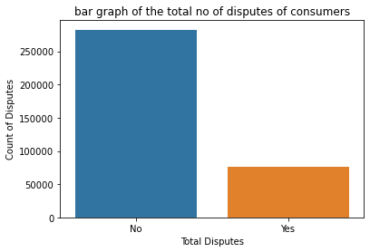

```python
sns.barplot(x=total_disputes.index, y=total_disputes.values , data=df_train)
plt.xlabel('Total Disputes')
plt.ylabel('Count of Disputes')
plt.title('bar graph of the total no of disputes of consumers')
plt.show()
```

# Plot bar graph of the total no of disputes products-wise with the help of seaborn

```python
Product_dispute = df_train[df_train['Consumer disputed?']== 'Yes'].groupby('Product')['Consumer disputed?'].value_counts()
Product_dispute
```

```
Product                  Consumer disputed?
Bank account or service  Yes                    8245
Consumer Loan            Yes                    3324
Credit card              Yes                    9409
Credit reporting         Yes                   10806
Debt collection          Yes                   12776
Money transfers          Yes                     382
Mortgage                 Yes                   28080
Other financial service  Yes                      90
Payday loan              Yes                     408
Prepaid card             Yes                     255
Student loan             Yes                    2395
Virtual currency         Yes                       2
Name: Consumer disputed?, dtype: int64
```

```python
Product_dispute.index.to_list()
```

```
[('Bank account or service', 'Yes'),
 ('Consumer Loan', 'Yes'),
 ('Credit card', 'Yes'),
 ('Credit reporting', 'Yes'),
 ('Debt collection', 'Yes'),
 ('Money transfers', 'Yes'),
 ('Mortgage', 'Yes'),
 ('Other financial service', 'Yes'),
 ('Payday loan', 'Yes'),
 ('Prepaid card', 'Yes'),
 ('Student loan', 'Yes'),
 ('Virtual currency', 'Yes')]
```

```python
product_labels=[]
for i in Product_dispute.index.to_list():
    product_labels.append(i[0])
```

```python
product_labels
```

```
['Bank account or service',
 'Consumer Loan',
 'Credit card',
 'Credit reporting',
 'Debt collection',
 'Money transfers',
 'Mortgage',
 'Other financial service',
 'Payday loan',
 'Prepaid card',
 'Student loan',
 'Virtual currency']
```

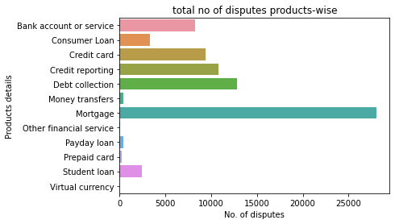

```python
plt.figure()
sns.barplot(x=Product_dispute.values , y= product_labels)
plt.xlabel('No. of disputes')
plt.ylabel('Products details')
plt.title('total no of disputes products-wise')
plt.show()
```